# Alzheimer’s disease

Lovdip Singh

## Question of interest/goal of the study

We are interested in whether FDG scores are different between normal individuals and AD patients. If there is a difference, does this difference depends on age?

## Read in and inspect the data:

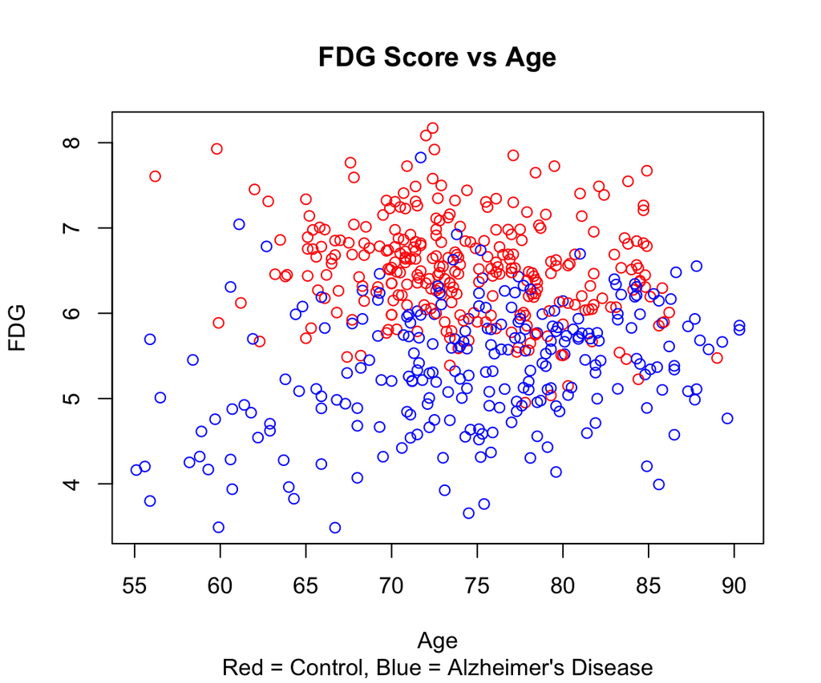

```r
adni.df=read.table("ADNI.txt",header=T)
color=rep('black',nrow(adni.df))
color[adni.df$Status=="AD"]="blue"
color[adni.df$Status=="CN"]="red"
plot(FDG~Age,data=adni.df,col=color,main="FDG Score vs Age",sub="Red = Control, Blue = Alzheimer's Disease")
```

The control group appears to have a higher FDG score on average compared to AD group. The control group appears to have a slight negative linear relationship with age, whereas the AD group appears to have a slight positive linear relationship. The variability appears to be slightly larger for people with AD.

## Model fitting

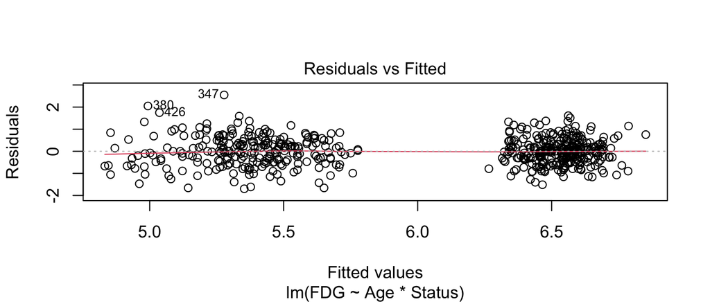

```r
adni.lm1=lm(FDG~Age*Status,data=adni.df)
plot(adni.lm1,which=1)
```

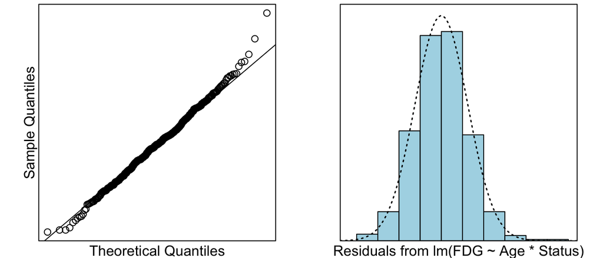

```r
normcheck(adni.lm1)
```

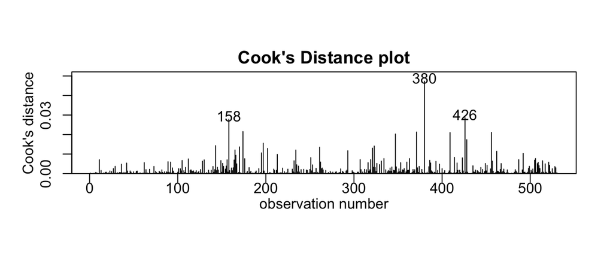

```r
cooks20x(adni.lm1)
```

## Data with model superimposed

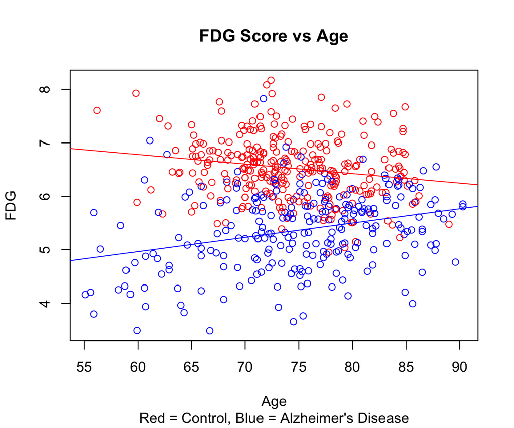

```r
plot(FDG~Age,data=adni.df,col=color,main="FDG Score vs Age",sub="Red = Control, Blue = Alzheimer's Disease")
abline(adni.lm1$coef[1],adni.lm1$coef[2],col="blue")
abline(adni.lm1$coef[1]+adni.lm1$coef[3],adni.lm1$coef[2]+adni.lm1$coef[4], col="red" )
```

The two clusters in the residual plot represents the two groups in this case control study. The cluster on the left represents the AD group and the control group is the cluster on the right of the plot. This is because AD group is the baseline group. The fitted values take into consideration the group, and since the control group is not baseline, they will have higher fitted values.

## Output from first model.

```r
summary(adni.lm1)
```

```
##
## Call:
## lm(formula = FDG ~ Age * Status, data = adni.df)
##
## Residuals:
##      Min       1Q   Median       3Q      Max
## -1.69699 -0.40369  0.00018  0.37965  2.54848
##
## Coefficients:
##               Estimate Std. Error t value Pr(>|t|)
## (Intercept)   3.354522   0.385517   8.701  < 2e-16 ***
## Age           0.026822   0.005115   5.244 2.28e-07 ***
## StatusCN      4.499591   0.603837   7.452 3.80e-13 ***
## Age:StatusCN -0.044670   0.008069  -5.536 4.89e-08 ***
## ---
## Signif. codes:  0 '***' 0.001 '**' 0.01 '*' 0.05 '.' 0.1 ' ' 1
##
## Residual standard error: 0.6246 on 527 degrees of freedom
## Multiple R-squared:  0.4836, Adjusted R-squared:  0.4806
## F-statistic: 164.5 on 3 and 527 DF,  p-value: < 2.2e-16
```

```r
confint(adni.lm1)
```

```
##                    2.5 %      97.5 %
## (Intercept)   2.59718306  4.11186155
## Age           0.01677362  0.03687132
## StatusCN      3.31336858  5.68581315
## Age:StatusCN -0.06052069 -0.02881862
```

## Rotate factor

```r
adni.df$StatusR=factor(adni.df$Status,levels=c("CN","AD"))
adni.lm2=lm(FDG~Age*StatusR,data=adni.df)
summary(adni.lm2)
```

```
##
## Call:
## lm(formula = FDG ~ Age * StatusR, data = adni.df)
##
## Residuals:
##      Min       1Q   Median       3Q      Max
## -1.69699 -0.40369  0.00018  0.37965  2.54848
##
## Coefficients:
##                Estimate Std. Error t value Pr(>|t|)
## (Intercept)    7.854113   0.464753  16.900  < 2e-16 ***
## Age           -0.017847   0.006240  -2.860   0.0044 **
## StatusRAD     -4.499591   0.603837  -7.452 3.80e-13 ***
## Age:StatusRAD  0.044670   0.008069   5.536 4.89e-08 ***
## ---
## Signif. codes:  0 '***' 0.001 '**' 0.01 '*' 0.05 '.' 0.1 ' ' 1
##
## Residual standard error: 0.6246 on 527 degrees of freedom
## Multiple R-squared:  0.4836, Adjusted R-squared:  0.4806
## F-statistic: 164.5 on 3 and 527 DF,  p-value: < 2.2e-16
```

```r
confint(adni.lm2)
```

```
##                     2.5 %       97.5 %
## (Intercept)    6.94111778  8.767108554
## Age           -0.03010590 -0.005588483
## StatusRAD     -5.68581315 -3.313368579
## Age:StatusRAD  0.02881862  0.060520694
```

## Method and Assumption Checks

There were two explanatory variables to consider, one numeric (age) and one factor (AD or control). A linear model that was fitted that used a different intercept and slope for AD and control groups. The interaction term was statistically significant therefore was not dropped from the model. All model assumption were satisfied.

Our final model is

$$FDG_i = \beta_o + \beta_1 \times age_i + \beta_2 \times status_i + \beta_3 \times age_i \times status_i + \epsilon_i$$
Where $status_i = 1$ if the person has AD, otherwise 0, $\epsilon_i \sim iid ~ N(0,\sigma^2)$.

Our model explained 48.4% of the variability in FDG score.

### Age:StatusCN

This coefficient is estimating the difference in the slope between the control group and AD group. For example, the coeffecient of Age:StatusCN + the coeffecient of Age is the slope for the control group.

### - the effect on the FDG scores for each additional years aging on healthy people.

For each additional year of age, the FDG score for healthy people decreases between 0.03 and 0.006 points on average.

### - the effect on the FDG scores for each additional years aging on people with Alzheimer’s disease.

The FDG score for people with AD increases between 0.017 to 0.037 points for each additional year of age on average.

For people with AD, as their age increases, their FDG score appears to increase, whereas for healthy people, their FDG score appears to decrease with age. The difference for the average FDG score between two people of the same age but different groups, i.e. a healthy person vs a person with AD of the same age, appears to decrease as age increases. For example, the difference in average FDG score for a healthy person vs a person with AD is much larger at age 55 and relatively smaller at age 90.

## Plot of prediction intervals for FDG scores verses age ranges for the two groups

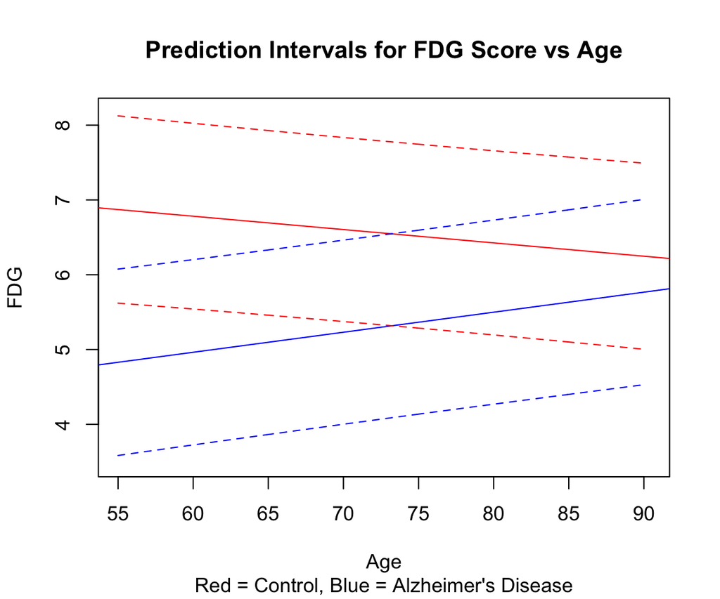

```r
plot(FDG~Age,data=adni.df,main="Prediction Intervals for FDG Score vs Age",sub="Red = Control, Blue = Alzheimer's Disease",type="n")
abline(adni.lm1$coef[1],adni.lm1$coef[2],col="blue")
abline(adni.lm1$coef[1]+adni.lm1$coef[3],adni.lm1$coef[2]+adni.lm1$coef[4], col="red" )


ages=seq(55,90,by=0.1)
predAD=as.factor(rep("AD",length(ages)))
predCN=as.factor(rep("CN",length(ages)))

new.dat1=data.frame(Age=ages, Status=predAD)
new.dat2=data.frame(Age=ages, Status=predCN)

predAD=predict(adni.lm1, newdata=new.dat1, interval="predict")
predCN=predict(adni.lm1, newdata=new.dat2, interval="predict")

lines(ages,predCN[1:length(ages),"lwr"],lty=2, col="red" )
lines(ages,predCN[1:length(ages),"upr"],lty=2, col="red" )
lines(ages,predAD[1:length(ages),"lwr"],lty=2, col="blue" )
lines(ages,predAD[1:length(ages),"upr"],lty=2, col="blue" )
```

It is plausible to predict AD earlier. From the plot we can see that there is less overlap between the prediction intervals for people with AD and healthy individuals, at earlier ages. As age increase, the overlap between the prediction intervals for the two groups increases. From this we can deduce that a lower FDG score, approximately under 6, at an age of around 55 years, the person is more likely to have AD than not have AD. However the same cannot be said at later ages, as the interval where the prediction intervals between the two groups overlap is much larger. This indicates that predicting AD at later ages becomes increasingly difficult as it is harder to determine which group the individual falls into based on their FDG score, i.e one with AD or a healthy person.